# Transformations and diagnostics

Fall 2022: Peter Ralph

https://uodsci.github.io/dsci345

# An example

Let's look at how newborn (i.e., "neonate") body mass is related to adult body mass, across a bunch of mammal species (in the order Carnivora, including dogs, cats, bears, weasels, and seals). [(data link)](https://github.com/UOdsci/dsci345/blob/main/class_material/slides/data/carnivora_sizes.csv)

```python
carnivores = pd.read_csv("data/carnivora_sizes.csv").set_index("Binomial")
carnivores
```

| Binomial | Family | NeonateBodyMass_g | AdultBodyMass_g | AgeatEyeOpening_d | WeaningAge_d |
| --- | --- | --- | --- | --- | --- |
| Canis aureus | Canidae | 211.82 | 9658.70 | 7.50 | 61.30 |
| Canis latrans | Canidae | 200.01 | 11989.10 | 11.94 | 43.71 |
| Canis lupus | Canidae | 412.31 | 31756.51 | 14.01 | 44.82 |
| Canis mesomelas | Canidae | 177.20 | 8247.30 | NaN | 34.10 |
| Callorhinus ursinus | Otariidae | 5354.80 | 55464.82 | 0.00 | 108.69 |
| ... | ... | ... | ... | ... | ... |
| Vulpes lagopus | Canidae | 69.17 | 3584.37 | 15.03 | 49.50 |
| Vulpes velox | Canidae | 39.94 | 2088.00 | 12.50 | 47.08 |
| Vulpes vulpes | Canidae | 100.49 | 4820.36 | 14.01 | 50.71 |
| Vulpes zerda | Canidae | 28.04 | 1317.13 | 16.95 | 65.56 |
| Zalophus californianus | Otariidae | 6347.89 | 137194.86 | 0.00 | 319.01 |

145 rows × 5 columns

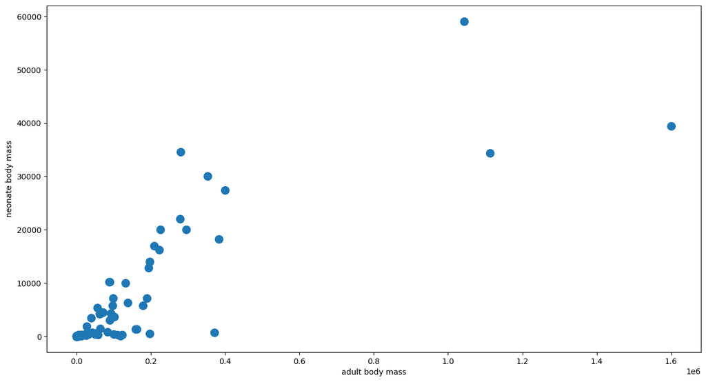

```python
plt.scatter(carnivores.AdultBodyMass_g, carnivores.NeonateBodyMass_g, s=100);
plt.xlabel("adult body mass"); plt.ylabel("neonate body mass");
```

But - there's some "substructure"!

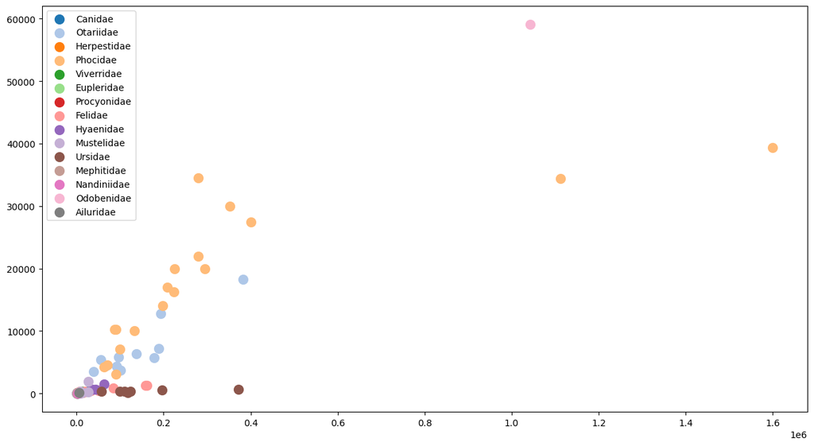

```python
colors = {f: c for f, c in zip(carnivores.Family.unique(), plt.cm.tab20.colors)}
for f in colors:
    sub = carnivores[carnivores.Family == f]
    plt.scatter(sub.AdultBodyMass_g, sub.NeonateBodyMass_g, color=colors[f], s=100, label=f)
plt.legend();
```

# First pass: a normal linear model

Let's fit a linear model and see what it's predictions are like:

```python
from sklearn.linear_model import LinearRegression as lm
fit1 = lm().fit(carnivores[['AdultBodyMass_g']], carnivores.NeonateBodyMass_g)
```

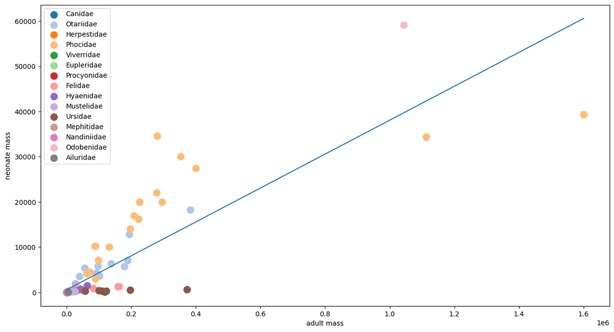

```python
for f in colors:
    sub = carnivores[carnivores.Family == f]
    plt.scatter(sub.AdultBodyMass_g, sub.NeonateBodyMass_g, color=colors[f], s=100, label=f)
pred = pd.DataFrame({ "AdultBodyMass_g": np.linspace(0, 1.6e6, 21) })
pred['NeonateBodyMass_g'] = fit1.predict(pred)
plt.plot(pred.AdultBodyMass_g, pred.NeonateBodyMass_g)
plt.xlabel("adult mass"); plt.ylabel("neonate mass"); plt.legend();
```

# Heteroskedasticity?

# Diagnostics

Two good generic diagnostic plots are:

1. residuals versus fitted
2. distribution of residuals (histogram or QQ plot)

*What's the idea?*

1. If the residuals show predictable patterns, we could improve our model,
2. and if the residual SD differs systematically, we have *heteroskedasticity* (and so our model isn't using all the data very well).

## Patterns in the residuals

Here's data that are nonlinear but we don't know it:

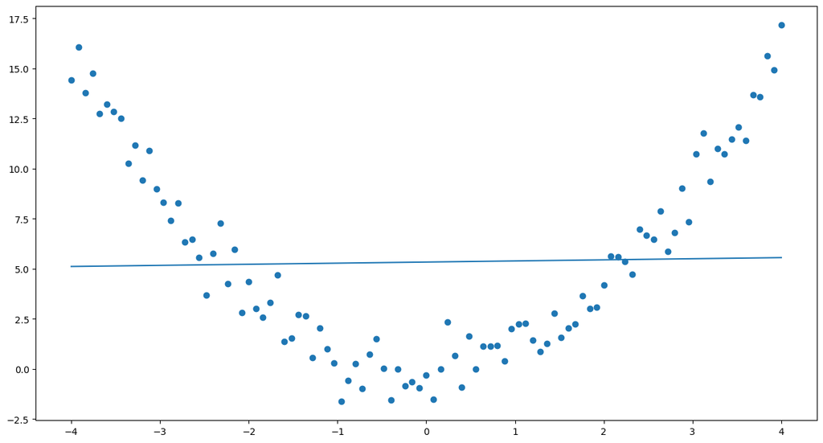

```python
X = np.array([np.linspace(-4, 4, 101)]).T
y = rng.normal(loc=X**2, scale=1)
xy_lm = lm().fit(X, y)
yhat = xy_lm.predict(X)
plt.scatter(X[:,0], y)
plt.plot(X[:,0], yhat);
```

And, this shows up in the fit-versus-residuals plot:

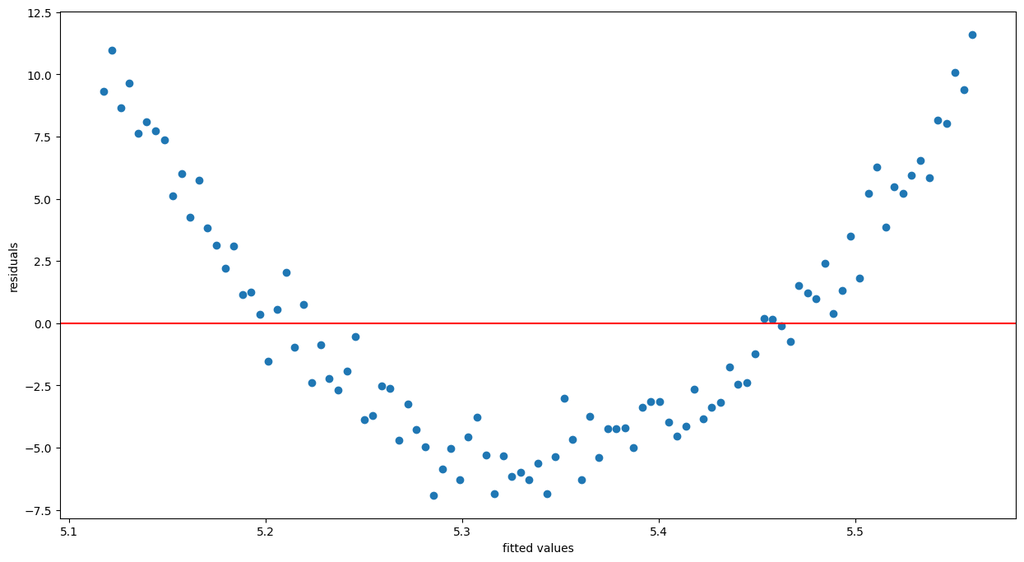

```python
resids = y - yhat
plt.scatter(yhat, resids);
plt.axhline(0, color='red')
plt.xlabel("fitted values"); plt.ylabel("residuals");
```

Solution: add a quadratic term!

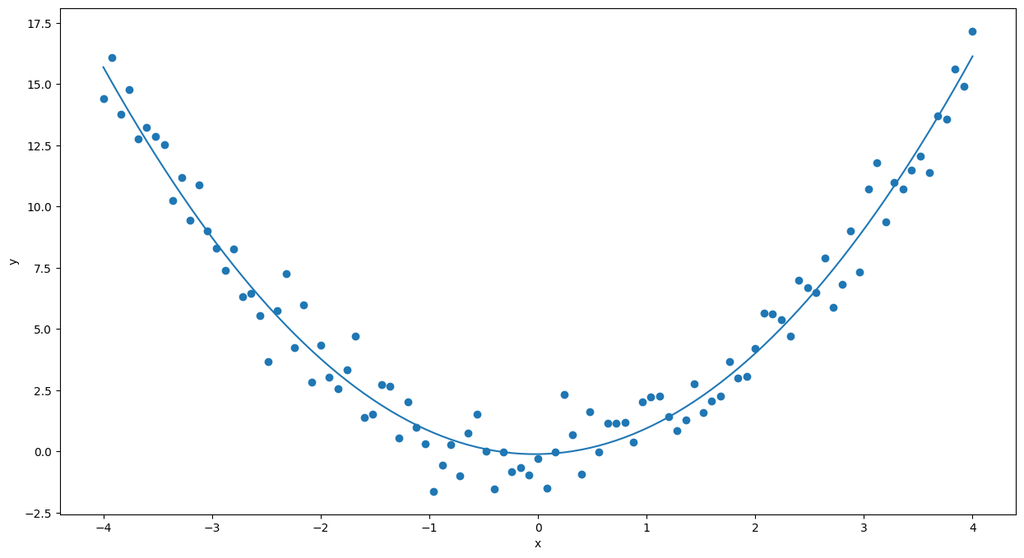

```python
XX2 = np.hstack([X, X**2])
xy_lm = lm().fit(XX2, y)
yhat = xy_lm.predict(XX2)
plt.scatter(X[:,0], y); plt.plot(X[:,0], yhat); plt.xlabel("x"); plt.ylabel('y');
```

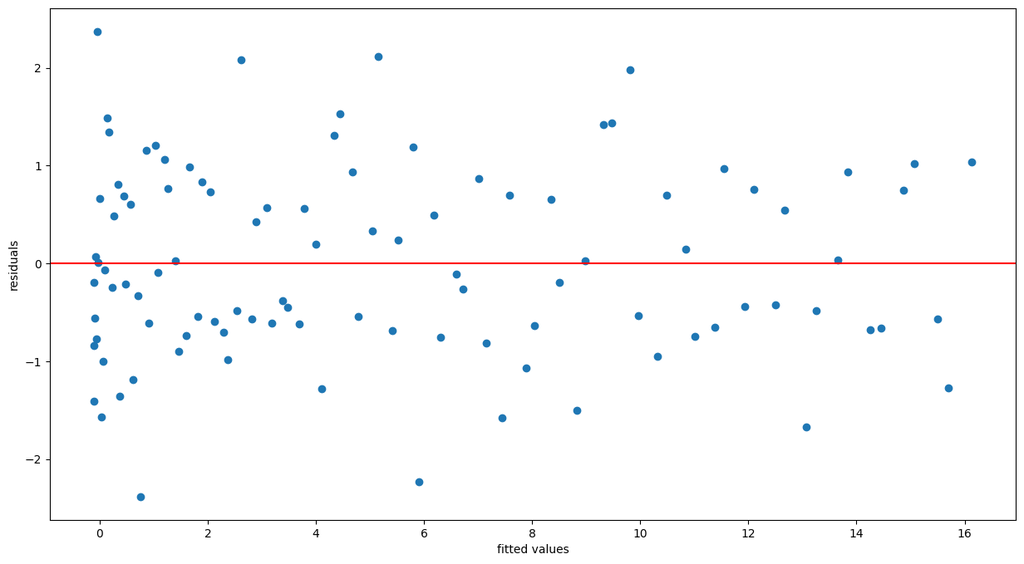

```python
resids = y - yhat
plt.scatter(yhat, resids);
plt.axhline(0, color='red')
plt.xlabel("fitted values"); plt.ylabel("residuals");
```

# Back to our data

Let's look at this in our data:

```python
carnivores['PredictedNeonateMass'] = fit1.predict(
    carnivores[['AdultBodyMass_g']]
)
carnivores['residual'] = carnivores['NeonateBodyMass_g'] - carnivores['PredictedNeonateMass']
```

```python
carnivores
```

[output not shown]

145 rows × 9 columns

No particular pattern (?), but certainly: heteroskedasticity!

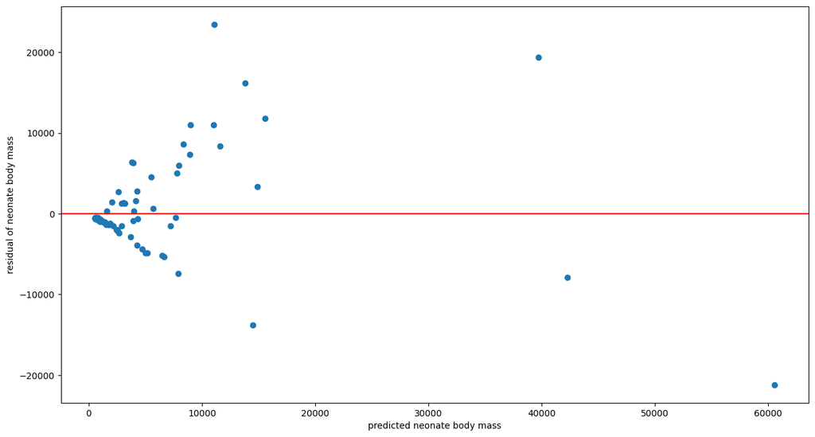

```python
plt.scatter(carnivores.PredictedNeonateMass, carnivores.residual)
plt.axhline(0, color='red');
plt.xlabel("predicted neonate body mass"); plt.ylabel("residual of neonate body mass");
```

Why is heteroskedasticity a problem? Above, we see that small body masses are all very close to the predicted line. Indeed they have to be! A 5g weasel can't have a 100kg baby. So: these small animals are not affecting the fit of that line very much at all. Maybe that's okay - if we're interested in a relationship that holds only for big animals, for instance - but we should dig more.

# A transformation

One reason for having bad model fit is that you aren't looking at the data through the right lens.

Most commonly: if the data vary by *percent changes*, then using standard methods (that assume *additive changes*) won't do so great. But, the **logarithm** turns percent changes into additive changes!

Let's try it out.

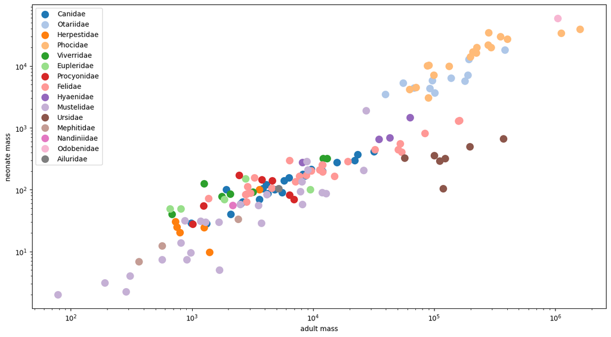

```python
for f in colors:
    sub = carnivores[carnivores.Family == f]
    plt.scatter(sub.AdultBodyMass_g, sub.NeonateBodyMass_g, color=colors[f], s=100, label=f)
plt.xscale("log"); plt.yscale("log")  # log-log axes
plt.xlabel("adult mass"); plt.ylabel("neonate mass"); plt.legend();
```

Okay, let's now fit a model to log(adult) and log(neonate) mass:

```python
carnivores['logAdultBodyMass_g'] = np.log(carnivores['AdultBodyMass_g'])
carnivores['logNeonateBodyMass_g'] = np.log(carnivores['NeonateBodyMass_g'])
fit2 = lm().fit(carnivores[['logAdultBodyMass_g']], carnivores.logNeonateBodyMass_g)
carnivores
```

| Binomial | Family | NeonateBodyMass_g | AdultBodyMass_g | AgeatEyeOpening_d | WeaningAge_d | PredictedNeonateMass | residual | logAdultBodyMass_g | logNeonateBodyMass_g |
| --- | --- | --- | --- | --- | --- | --- | --- | --- | --- |
| Canis aureus | Canidae | 211.82 | 9658.70 | 7.50 | 61.30 | 916.205446 | -704.385446 | 9.175614 | 5.355737 |
| Canis latrans | Canidae | 200.01 | 11989.10 | 11.94 | 43.71 | 1003.630922 | -803.620922 | 9.391753 | 5.298367 |
| Canis lupus | Canidae | 412.31 | 31756.51 | 14.01 | 44.82 | 1745.209715 | -1332.899715 | 10.365853 | 6.021775 |
| Canis mesomelas | Canidae | 177.20 | 8247.30 | NaN | 34.10 | 863.256460 | -686.056460 | 9.017641 | 5.177279 |
| Callorhinus ursinus | Otariidae | 5354.80 | 55464.82 | 0.00 | 108.69 | 2634.632251 | 2720.167749 | 10.923504 | 8.585749 |
| ... | ... | ... | ... | ... | ... | ... | ... | ... | ... |
| Vulpes lagopus | Canidae | 69.17 | 3584.37 | 15.03 | 49.50 | 688.325602 | -619.155602 | 8.184338 | 4.236567 |
| Vulpes velox | Canidae | 39.94 | 2088.00 | 12.50 | 47.08 | 632.188948 | -592.248948 | 7.643962 | 3.687378 |
| Vulpes vulpes | Canidae | 100.49 | 4820.36 | 14.01 | 50.71 | 734.694042 | -634.204042 | 8.480604 | 4.610058 |
| Vulpes zerda | Canidae | 28.04 | 1317.13 | 16.95 | 65.56 | 603.269588 | -575.229588 | 7.183210 | 3.333632 |
| Zalophus californianus | Otariidae | 6347.89 | 137194.86 | 0.00 | 319.01 | 5700.752923 | 647.137077 | 11.829158 | 8.755878 |

145 rows × 9 columns

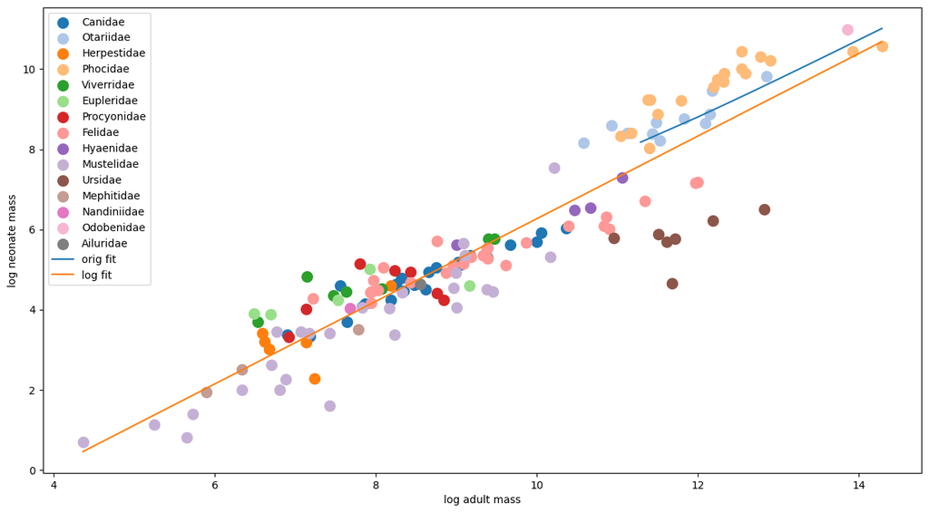

```python
for f in colors:
    sub = carnivores[carnivores.Family == f]
    plt.scatter(sub.logAdultBodyMass_g, sub.logNeonateBodyMass_g, color=colors[f], s=100, label=f)
pred2 = pd.DataFrame({
    "logAdultBodyMass_g": np.linspace(np.min(carnivores.logAdultBodyMass_g),
                                      np.max(carnivores.logAdultBodyMass_g), 201)
})
pred2['logNeonateBodyMass_g'] = fit2.predict(pred2)
plt.plot(np.log(pred.AdultBodyMass_g), np.log(pred.NeonateBodyMass_g), label='orig fit')
plt.plot(pred2.logAdultBodyMass_g, pred2.logNeonateBodyMass_g, label='log fit')
plt.xlabel("log adult mass"); plt.ylabel("log neonate mass"); plt.legend();
```

## Conclusions?

1. taking logs is definitely the way to fit these data
2. each family looks to have a different relationship
3. so a better model would allow different lines for each family

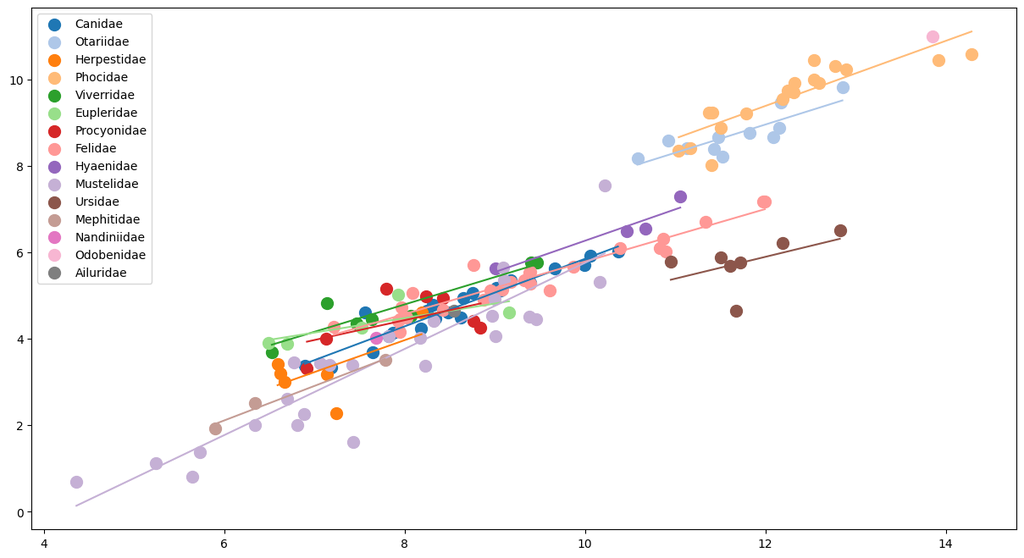

```python
for f in colors:
    sub = carnivores[carnivores.Family == f]
    fit_sub = lm().fit(sub[['logAdultBodyMass_g']], sub.logNeonateBodyMass_g)
    plt.scatter(sub.logAdultBodyMass_g, sub.logNeonateBodyMass_g, color=colors[f], s=100, label=f)
    pred_sub = pd.DataFrame({
        "logAdultBodyMass_g": np.linspace(np.min(sub.logAdultBodyMass_g),
                                          np.max(sub.logAdultBodyMass_g), 201)
    })
    pred_sub['logNeonateBodyMass_g'] = fit_sub.predict(pred_sub)
    plt.plot(pred_sub.logAdultBodyMass_g, pred_sub.logNeonateBodyMass_g, color=colors[f])
plt.legend();
```

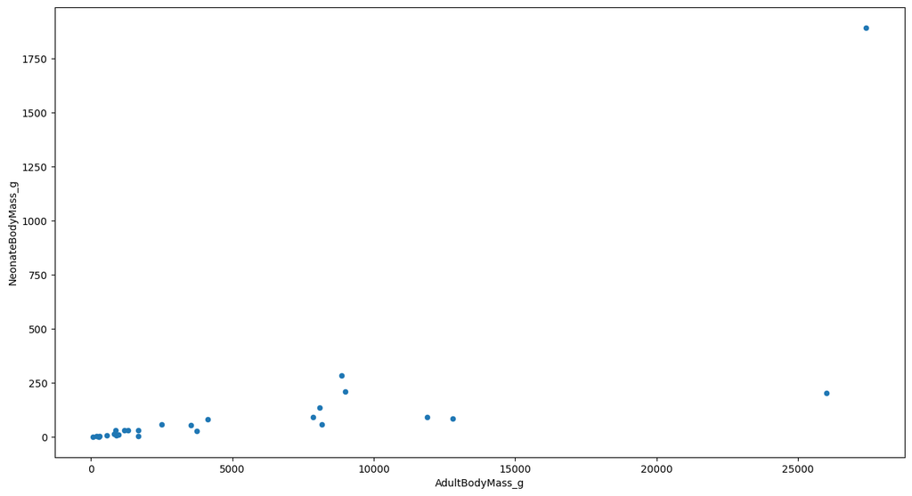

```python
carnivores[carnivores.Family == "Mustelidae"].plot.scatter("AdultBodyMass_g", "NeonateBodyMass_g")
```

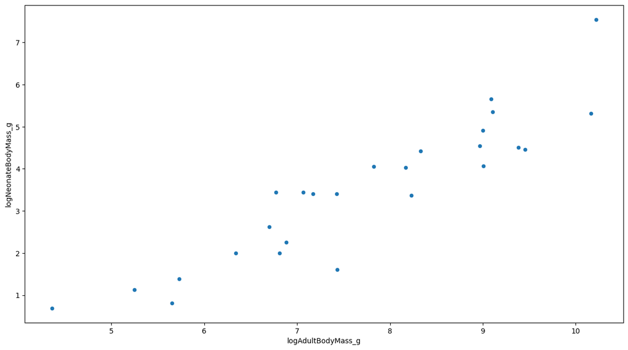

```python
carnivores[carnivores.Family == "Mustelidae"].plot.scatter("logAdultBodyMass_g", "logNeonateBodyMass_g")
```

Next steps:

- fit the model with the additional variables to see if maybe we don't need separate models by family any more?

```python
non_na = carnivores[~np.isnan(carnivores.AgeatEyeOpening_d)]
non_na = non_na[~np.isnan(non_na.WeaningAge_d)]
fit3 = lm().fit(non_na[['logAdultBodyMass_g', "AgeatEyeOpening_d", "WeaningAge_d"]], non_na.logNeonateBodyMass_g)
```

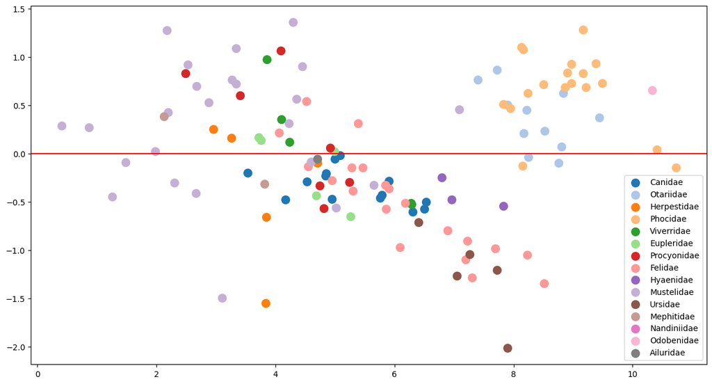

```python
non_na['predicted'] = fit3.predict(non_na[['logAdultBodyMass_g', "AgeatEyeOpening_d", "WeaningAge_d"]])
non_na['resid'] = non_na.logNeonateBodyMass_g - non_na['predicted']

for f in colors:
    sub = non_na[non_na.Family == f]
    plt.scatter(sub.predicted, sub.resid, color=colors[f], s=100, label=f)
plt.axhline(0, color='red')
plt.legend();
```